# Application de méthodes d’apprentissage statistique à l’analyse de données de grains de raisins

Auteurs: Cynthia LACROIX HERKENHOFF; Bruno MACEDO SANCHES

```r
require(knitr)
## Definition du dossier, CHANGER ICI
opts_knit$set(root.dir = "c:/Users/bruno/Projet_STA203/")
```

```r
# Nettoyage de l'environnement
rm(list=objects())
graphics.off()
```

# Chargement de libraries et collecte de données

```r
library("readxl", quietly=TRUE)
library("dplyr", quietly=TRUE)
library("ggplot2", quietly=TRUE)
library("cowplot", quietly=TRUE)
library("GGally", quietly=TRUE)
library("FactoMineR", quietly=TRUE)
library("reshape2", quietly=TRUE)
library("psych", quietly=TRUE)
library("stats", quietly=TRUE)
library("MASS", quietly=TRUE)
library("purrr", quietly=TRUE)
library("NMOF", quietly=TRUE)
library("glmnet", quietly=TRUE)
library("e1071", quietly=TRUE)
library("pROC", quietly=TRUE)
```

```r
df = read_excel("data/Raisin.xlsx")
head(df)
```

| Area | MajorAxisLength | MinorAxisLength | Eccentricity | ConvexArea | Extent | Perimeter | Class |
| --- | --- | --- | --- | --- | --- | --- | --- |
| 87524 | 442.2460 | 253.2912 | 0.8197384 | 90546 | 0.7586506 | 1184.040 | Kecimen |
| 75166 | 406.6907 | 243.0324 | 0.8018052 | 78789 | 0.6841296 | 1121.786 | Kecimen |
| 90856 | 442.2670 | 266.3283 | 0.7983536 | 93717 | 0.6376128 | 1208.575 | Kecimen |
| 45928 | 286.5406 | 208.7600 | 0.6849892 | 47336 | 0.6995994 | 844.162 | Kecimen |
| 79408 | 352.1908 | 290.8275 | 0.5640113 | 81463 | 0.7927719 | 1073.251 | Kecimen |
| 49242 | 318.1254 | 200.1221 | 0.7773513 | 51368 | 0.6584564 | 881.836 | Kecimen |

# Partie I: Analyse non supervisée

## Analyses uni et vi-variées

On commence l’analyse des données par l’exploration du *dataset*

```r
df %>%
  group_by(Class) %>%
  count()
```

| Class | n |
| --- | --- |
| Besni | 450 |
| Kecimen | 450 |

[output not shown]

On a 2 classes, chacun avec 450 observations, donc le jeu de données est équilibrée. On fait l’analyse en séparant ce jeu de donnés en deux

```r
summary(df[df$Class == 'Kecimen',])
```

```
      Area        MajorAxisLength MinorAxisLength  Eccentricity      ConvexArea         Extent
 Min.   : 25387   Min.   :225.6   Min.   :143.7   Min.   :0.3487   Min.   : 26139   Min.   :0.4542
 1st Qu.: 50466   1st Qu.:313.5   1st Qu.:205.2   1st Qu.:0.7043   1st Qu.: 52115   1st Qu.:0.6808
 Median : 61420   Median :350.2   Median :228.6   Median :0.7665   Median : 63827   Median :0.7103
 Mean   : 63413   Mean   :352.9   Mean   :229.4   Mean   :0.7420   Mean   : 65696   Mean   :0.7078
 3rd Qu.: 75153   3rd Qu.:390.4   3rd Qu.:250.8   3rd Qu.:0.8020   3rd Qu.: 77504   3rd Qu.:0.7376
 Max.   :180898   Max.   :844.0   Max.   :326.9   Max.   :0.9238   Max.   :221396   Max.   :0.8355
   Perimeter         Class
 Min.   : 619.1   Length:450
 1st Qu.: 885.1   Class :character
 Median : 977.9   Mode  :character
 Mean   : 983.7
 3rd Qu.:1073.2
 Max.   :2253.6
```

```r
summary(df[df$Class == 'Besni',])
```

```
      Area        MajorAxisLength MinorAxisLength  Eccentricity      ConvexArea         Extent
 Min.   : 40702   Min.   :274.2   Min.   :172.5   Min.   :0.5010   Min.   : 41924   Min.   :0.3799
 1st Qu.: 83599   1st Qu.:436.5   1st Qu.:242.6   1st Qu.:0.7880   1st Qu.: 87668   1st Qu.:0.6563
 Median :104427   Median :493.2   Median :273.4   Median :0.8320   Median :108063   Median :0.7029
 Mean   :112195   Mean   :509.0   Mean   :279.6   Mean   :0.8211   Mean   :116676   Mean   :0.6912
 3rd Qu.:135683   3rd Qu.:582.4   3rd Qu.:308.3   3rd Qu.:0.8688   3rd Qu.:139780   3rd Qu.:0.7335
 Max.   :235047   Max.   :997.3   Max.   :492.3   Max.   :0.9621   Max.   :278217   Max.   :0.8306
   Perimeter         Class
 Min.   : 771.8   Length:450
 1st Qu.:1182.3   Class :character
 Median :1305.8   Mode  :character
 Mean   :1348.1
 3rd Qu.:1510.5
 Max.   :2697.8
```

A partir de ces résultats, on voit une différence principalement entre les valeurs de *Area* et *ConvexArea* entre les deux classes éxistantes, on explorera cela après.

On plote les boxplots de chaque variable

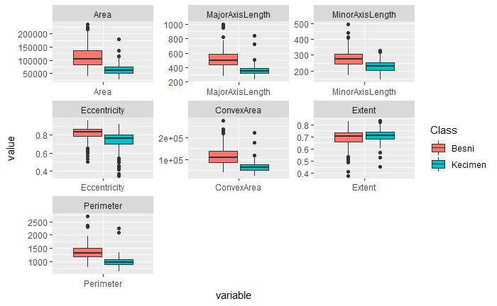

```r
df.m <- melt(df, id.var="Class")

ggplot(df.m, aes(x=variable, y=value)) +
  geom_boxplot(aes(fill=Class)) +
  facet_wrap(~variable, scales="free")
```

On voit que pour quelques variables (e.g *Area* et *Perimeter*) il y a une différence claire entre les deux classes. Ça peut expliquer un peu le résultat de l’article vue que les données seront plus faciles de séparer

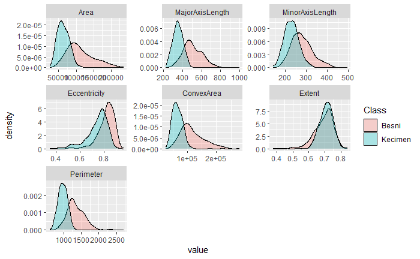

```r
ggplot(df.m, aes(x=value, fill=Class)) +
  geom_density(kernel='gaussian', alpha=0.3) +
  facet_wrap(~variable, scales="free")
```

Les graphes de densité sont utiles pour voir que la différence constaté antérieurement ne sont pas très claires, cependant, il y existe encore une différence de distribution entre les deux classes.

On voit aussi que la variable *Extent* est similairement distribuée pour les deux classes, cette variable ne sera pas très utile lors d’analyses.

On commence donc a analyser la relation entre les variables

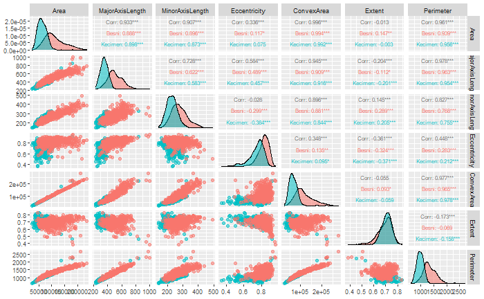

```r
ggpairs(df, columns=1:7, aes(color=Class, alpha=0.3),
        upper = list(continuous = wrap("cor", size=2)), progress=FALSE) +
  theme_grey(base_size=8)
```

On observe que la corrélation entre la variable Area et les variables *MajorAxisLength*, *MinorAxisLength*, *ConvexArea* et *Perimeter* est haute (0.933, 0.907, 0.996 et 0.961 respectivement). Ces variables ne sont pas indépendants et cela c’est claire vu que ces variables expliquent de certain façon la taille du grain.

## Analyse en composantes principales

On fait une analyse en composantes principales du jeu de données

```r
# On centre-réduit le jeu de donnés pour le bien traiter
df.cr <- data.frame(scale(df[-8], center=TRUE, scale=TRUE)/sqrt((nrow(df)-1)/nrow(df)))
df.cr$Class <- df$Class
describe(df.cr[-8])
```

|  | vars | n | mean | sd | median | trimmed | mad | min | max | range | skew | kurtosis | se |
| --- | --- | --- | --- | --- | --- | --- | --- | --- | --- | --- | --- | --- | --- |
| Area | 1 | 900 | 0 | 1 | -0.23 | -0.13 | 0.82 | -1.60 | 3.78 | 5.38 | 1.17 | 1.05 | 0.03 |
| MajorAxisLength | 2 | 900 | 0 | 1 | -0.20 | -0.09 | 0.91 | -1.77 | 4.88 | 6.65 | 0.99 | 1.30 | 0.03 |
| MinorAxisLength | 3 | 900 | 0 | 1 | -0.13 | -0.07 | 0.89 | -2.22 | 4.76 | 6.98 | 0.80 | 0.93 | 0.03 |
| Eccentricity | 4 | 900 | 0 | 1 | 0.19 | 0.12 | 0.82 | -4.79 | 2.00 | 6.80 | -1.32 | 2.46 | 0.03 |
| ConvexArea | 5 | 900 | 0 | 1 | -0.23 | -0.13 | 0.82 | -1.60 | 4.59 | 6.19 | 1.24 | 1.40 | 0.03 |
| Extent | 6 | 900 | 0 | 1 | 0.15 | 0.07 | 0.86 | -5.98 | 2.54 | 8.53 | -1.15 | 3.30 | 0.03 |
| Perimeter | 7 | 900 | 0 | 1 | -0.17 | -0.09 | 0.93 | -2.00 | 5.60 | 7.60 | 1.01 | 1.72 | 0.03 |

On calcule l’inertie de ce jeu de données

```r
mean(rowSums(df.cr[-8]^2))
```

```
[1] 7
```

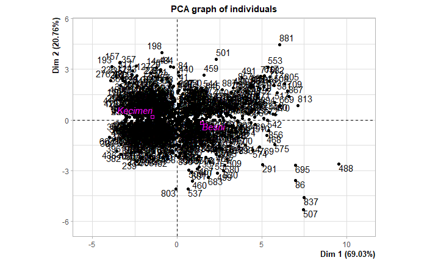

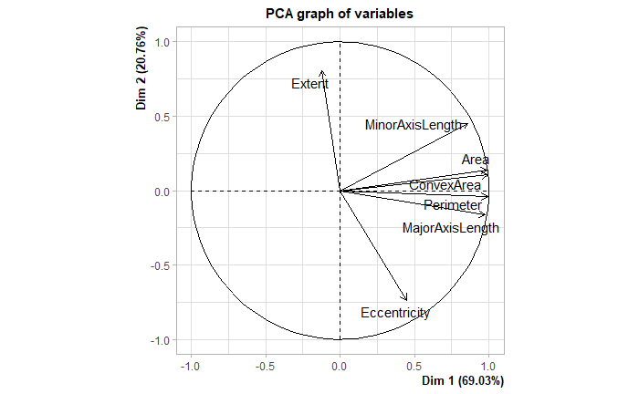

```r
pca_df <- PCA(df.cr, quali.sup=c(8), ncp=7)
```

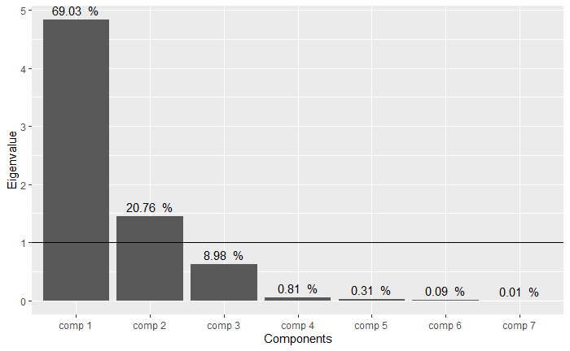

```r
ggplot(as.data.frame(pca_df$eig), aes(x=rownames(pca_df$eig), y=pca_df$eig[,1])) +
  geom_col() +
  geom_text(aes(label=paste(round(pca_df$eig[,2],2), " %")), vjust=-0.5) +
  geom_hline(aes(yintercept=1)) +
  labs(x="Components", y="Eigenvalue")
```

On voit que les deux premiers composantes principales de l’ACP expliquent presque 90% de la variance du jeu de données. La troisième composant possédé un valeur de moins de 1, c’est-à-dire, elle explique moins qu’une variable original. **Conclusion** On garde les deux premier composantes principales

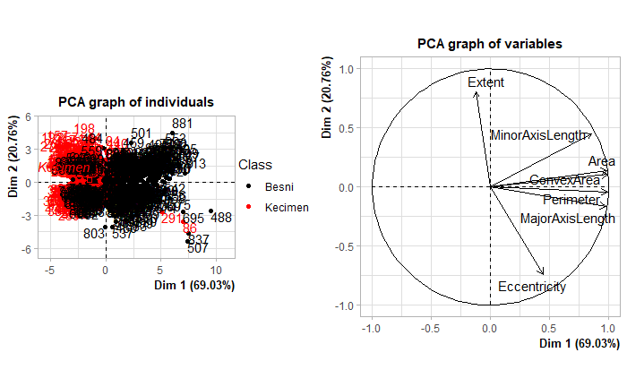

```r
p1 <- plot(pca_df, axes=c(1,2), choix='ind', habillage=8)
p2 <- plot(pca_df, axes=c(1,2), choix='var')
plot_grid(p1, p2)
```

On observe le circle de variables, les variables *Area*, *ConvexArea*, *Perimeter*, *MajorAxisLength* et *MinorAxisLength* sont positivement corrélées et bien expliqués par ces deux dimensions. Une interprétation possible de la première dimension est la surface du grain.

On observe le graphique d’individus, les individus de l’espèce Besni sont plus à droit, si on considère l’interprétation antérieur, ces individus sont normalement plus grandes que les individus de l’espèce Kecimen.

On plote aussi des graphes pour les composantes 2 et 3

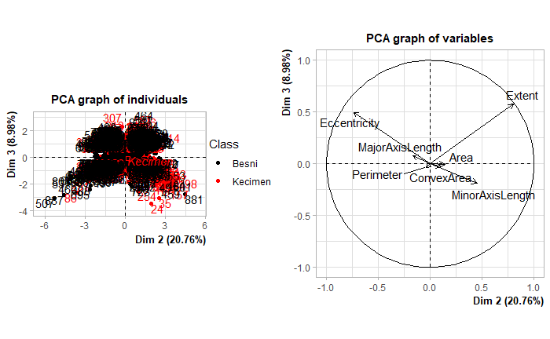

```r
p1 <- plot(pca_df, axes=c(2,3), choix='ind', habillage=8)
p2 <- plot(pca_df, axes=c(2,3), choix='var')
plot_grid(p1, p2)
```

On voit que la majorité des variables n’est pas bien expliquée, l’exception sont des variables *Eccentricity* et *Extent*. Cela montre que ces variables sont peut explicatives du jeu de donnée, on peut note ça aussi dans le graphique d’individus, oú il n’y a pas assez de différence entre les classes.

## Clustering

On comment l’analyse de cluster avec l’algorithme k-means. On calcule la somme de carrés d’accord avec le nombre de clusters

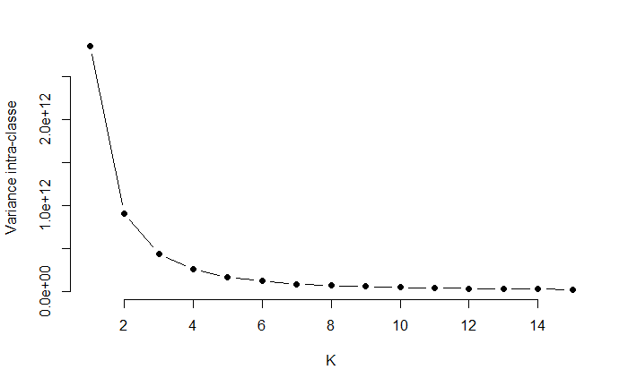

```r
set.seed(123)

# Calcule la variance intra-classe
wss <- function(k) {
  kmeans(df[-8], k, nstart = 10 )$tot.withinss
}
k.values <- 1:15
wss_values <- lapply(k.values, wss)
plot(k.values, wss_values,
     type="b", pch = 19, frame = FALSE,
       xlab="K",
       ylab="Variance intra-classe")
```

Si on utilise la méthode Elbow, on voit que garder 2 clusters est une bonne option, la variation de la variance intra classe se réduit après $k=2$.

On part à l’analyse de groupes en utilisant $k=2$

```r
km <- kmeans(df[-8], centers=2)
km
```

```
K-means clustering with 2 clusters of sizes 711, 189

Cluster means:
       Area MajorAxisLength MinorAxisLength Eccentricity ConvexArea    Extent Perimeter
1  71209.01        384.5485        236.4324    0.7677608   73877.08 0.7008132  1055.006
2 150233.37        605.4126        322.4120    0.8333862  156300.93 0.6945978  1583.103

Clustering vector:
  [1] 1 1 1 1 1 1 1 1 1 1 1 1 1 1 1 1 1 1 1 1 1 1 1 1 1 1 1 1 1 1 1 1 1 1 1 1 1 1 1 1 1 1 1 1 1 1 1 1 1 1 1 2 1 1
 [55] 1 1 1 1 1 1 1 1 1 1 1 1 1 1 1 1 1 1 1 1 1 1 1 1 1 1 1 1 1 1 1 2 1 1 1 1 1 1 1 1 1 1 1 1 1 1 1 1 1 1 1 1 1 1
[109] 1 1 1 1 1 1 1 1 1 1 1 1 1 1 1 1 1 1 1 1 1 1 1 1 1 1 1 1 1 1 1 1 1 1 1 1 1 1 1 1 1 1 1 1 1 1 1 1 1 1 1 1 1 1
[163] 1 1 1 1 1 1 1 1 1 1 1 1 1 1 1 1 1 1 1 1 1 1 1 1 1 1 1 1 1 1 1 1 1 1 1 1 1 1 1 1 1 1 1 1 1 1 1 1 1 1 1 1 1 1
[217] 1 1 1 1 1 1 1 1 1 1 1 1 1 1 1 1 1 1 1 1 1 1 1 1 1 1 1 1 1 1 1 1 1 1 1 1 1 1 1 1 1 1 1 1 1 1 1 1 1 1 1 1 1 1
[271] 1 1 1 1 1 1 1 1 1 1 1 1 1 1 1 1 1 1 1 1 2 1 1 1 1 1 1 1 1 1 1 1 1 1 1 1 1 1 1 1 1 1 1 1 1 1 1 1 1 1 1 1 1 1
[325] 1 1 1 1 1 1 1 1 1 1 1 1 1 1 1 1 1 1 1 1 1 1 1 1 1 1 1 1 1 1 1 1 1 1 1 1 1 1 1 1 1 1 1 1 1 1 1 1 1 1 1 1 1 1
[379] 1 1 1 1 1 1 1 1 1 1 1 1 1 1 1 1 1 1 1 1 1 1 1 1 1 1 1 1 1 1 1 1 1 1 1 1 1 1 1 1 1 1 1 1 1 1 1 1 1 1 1 1 1 1
[433] 1 1 1 1 1 1 1 1 1 1 1 1 1 1 1 1 1 1 2 2 1 1 1 2 2 2 2 1 1 1 2 1 2 1 1 2 2 2 1 2 1 2 1 2 2 1 2 2 2 1 2 1 2 1
[487] 1 2 1 1 2 1 1 1 1 2 2 1 2 1 2 2 1 2 1 1 2 2 2 2 1 1 1 1 2 2 2 1 1 1 2 1 2 2 1 2 1 2 2 1 1 1 1 2 2 1 1 1 2 1
[541] 2 2 2 2 1 1 1 2 2 1 1 1 2 1 1 2 1 1 1 2 2 2 1 2 1 2 2 2 2 1 1 1 1 2 2 2 1 2 2 2 2 2 2 2 1 1 2 1 2 1 2 1 2 2
[595] 2 1 1 1 1 2 1 2 1 2 1 2 1 1 1 2 1 1 2 2 1 1 2 2 1 1 1 2 2 2 1 1 1 1 1 1 1 1 1 1 2 1 1 2 1 1 1 2 1 1 2 2 1 1
[649] 1 2 2 1 1 1 2 1 2 2 1 1 1 2 1 1 1 1 2 1 2 1 2 2 1 1 1 2 1 2 2 2 1 2 1 1 1 1 1 2 1 1 1 2 2 1 2 1 1 1 1 2 2 2
[703] 2 2 2 1 1 1 2 1 1 2 1 1 1 1 1 1 1 1 1 1 2 1 1 1 1 2 1 1 1 1 1 1 1 2 2 1 2 1 1 2 1 1 1 1 2 2 1 1 1 2 1 1 2 2
[757] 2 1 1 2 2 1 1 1 1 2 1 2 2 2 2 2 1 1 1 1 2 2 2 1 1 2 1 1 1 1 2 1 2 1 1 2 1 1 1 1 1 1 1 1 2 2 1 2 2 1 2 1 1 1
[811] 2 1 2 2 1 2 1 1 1 1 2 2 1 1 1 1 1 1 1 2 2 1 1 1 2 1 2 2 1 1 1 1 1 1 1 2 1 2 1 1 1 1 1 2 1 2 2 2 1 2 2 1 1 1
[865] 2 2 2 1 2 1 2 1 1 1 1 1 2 2 2 1 2 2 1 2 1 1 2 1 1 1 1 1 2 2 2 1 1 1 1 1

Within cluster sum of squares by cluster:
[1] 569761126243 345272914401
 (between_SS / total_SS =  68.0 %)

Available components:

[1] "cluster"      "centers"      "totss"        "withinss"     "tot.withinss" "betweenss"    "size"
[8] "iter"         "ifault"
```

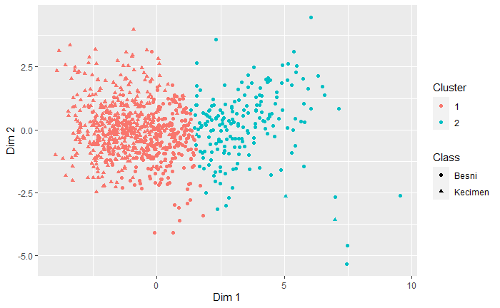

```r
ggplot(data=NULL, aes(x=pca_df$ind$coord[,1], y=pca_df$ind$coord[,2], color=as.factor(km$cluster), shape=df$Class)) +
  geom_point() +
  labs(x="Dim 1", y="Dim 2", shape="Class", color="Cluster")
```

On peut voir que l’algorithme *k-means* a séparée le jeu de donnés en deux *clusters* proches à la séparation en classes. Le cluster 2 comporte beaucoup de grains d’espèce Besni et peu d’espèce Kecimen. Le cluster 1 possédé une quantité raisonnable des deux classes, mais il comporte la majorité des individus d’espèce Kecimen.

On calcule l’erreur de classification pour ces deux clusters

```r
1 - mean((km$cluster == 1 & df$Class == "Kecimen") | (km$cluster == 2 & df$Class == "Besni"))
```

```
[1] 0.2966667
```

On obtient un erreur de 29.67% avec une classification en utilisant le k-means avec $k=2$.

```r
km.cr <- kmeans(df.cr[-8], centers=2)
km
```

```
K-means clustering with 2 clusters of sizes 711, 189

Cluster means:
       Area MajorAxisLength MinorAxisLength Eccentricity ConvexArea    Extent Perimeter
1  71209.01        384.5485        236.4324    0.7677608   73877.08 0.7008132  1055.006
2 150233.37        605.4126        322.4120    0.8333862  156300.93 0.6945978  1583.103

Clustering vector:
  [1] 1 1 1 1 1 1 1 1 1 1 1 1 1 1 1 1 1 1 1 1 1 1 1 1 1 1 1 1 1 1 1 1 1 1 1 1 1 1 1 1 1 1 1 1 1 1 1 1 1 1 1 2 1 1
 [55] 1 1 1 1 1 1 1 1 1 1 1 1 1 1 1 1 1 1 1 1 1 1 1 1 1 1 1 1 1 1 1 2 1 1 1 1 1 1 1 1 1 1 1 1 1 1 1 1 1 1 1 1 1 1
[109] 1 1 1 1 1 1 1 1 1 1 1 1 1 1 1 1 1 1 1 1 1 1 1 1 1 1 1 1 1 1 1 1 1 1 1 1 1 1 1 1 1 1 1 1 1 1 1 1 1 1 1 1 1 1
[163] 1 1 1 1 1 1 1 1 1 1 1 1 1 1 1 1 1 1 1 1 1 1 1 1 1 1 1 1 1 1 1 1 1 1 1 1 1 1 1 1 1 1 1 1 1 1 1 1 1 1 1 1 1 1
[217] 1 1 1 1 1 1 1 1 1 1 1 1 1 1 1 1 1 1 1 1 1 1 1 1 1 1 1 1 1 1 1 1 1 1 1 1 1 1 1 1 1 1 1 1 1 1 1 1 1 1 1 1 1 1
[271] 1 1 1 1 1 1 1 1 1 1 1 1 1 1 1 1 1 1 1 1 2 1 1 1 1 1 1 1 1 1 1 1 1 1 1 1 1 1 1 1 1 1 1 1 1 1 1 1 1 1 1 1 1 1
[325] 1 1 1 1 1 1 1 1 1 1 1 1 1 1 1 1 1 1 1 1 1 1 1 1 1 1 1 1 1 1 1 1 1 1 1 1 1 1 1 1 1 1 1 1 1 1 1 1 1 1 1 1 1 1
[379] 1 1 1 1 1 1 1 1 1 1 1 1 1 1 1 1 1 1 1 1 1 1 1 1 1 1 1 1 1 1 1 1 1 1 1 1 1 1 1 1 1 1 1 1 1 1 1 1 1 1 1 1 1 1
[433] 1 1 1 1 1 1 1 1 1 1 1 1 1 1 1 1 1 1 2 2 1 1 1 2 2 2 2 1 1 1 2 1 2 1 1 2 2 2 1 2 1 2 1 2 2 1 2 2 2 1 2 1 2 1
[487] 1 2 1 1 2 1 1 1 1 2 2 1 2 1 2 2 1 2 1 1 2 2 2 2 1 1 1 1 2 2 2 1 1 1 2 1 2 2 1 2 1 2 2 1 1 1 1 2 2 1 1 1 2 1
[541] 2 2 2 2 1 1 1 2 2 1 1 1 2 1 1 2 1 1 1 2 2 2 1 2 1 2 2 2 2 1 1 1 1 2 2 2 1 2 2 2 2 2 2 2 1 1 2 1 2 1 2 1 2 2
[595] 2 1 1 1 1 2 1 2 1 2 1 2 1 1 1 2 1 1 2 2 1 1 2 2 1 1 1 2 2 2 1 1 1 1 1 1 1 1 1 1 2 1 1 2 1 1 1 2 1 1 2 2 1 1
[649] 1 2 2 1 1 1 2 1 2 2 1 1 1 2 1 1 1 1 2 1 2 1 2 2 1 1 1 2 1 2 2 2 1 2 1 1 1 1 1 2 1 1 1 2 2 1 2 1 1 1 1 2 2 2
[703] 2 2 2 1 1 1 2 1 1 2 1 1 1 1 1 1 1 1 1 1 2 1 1 1 1 2 1 1 1 1 1 1 1 2 2 1 2 1 1 2 1 1 1 1 2 2 1 1 1 2 1 1 2 2
[757] 2 1 1 2 2 1 1 1 1 2 1 2 2 2 2 2 1 1 1 1 2 2 2 1 1 2 1 1 1 1 2 1 2 1 1 2 1 1 1 1 1 1 1 1 2 2 1 2 2 1 2 1 1 1
[811] 2 1 2 2 1 2 1 1 1 1 2 2 1 1 1 1 1 1 1 2 2 1 1 1 2 1 2 2 1 1 1 1 1 1 1 2 1 2 1 1 1 1 1 2 1 2 2 2 1 2 2 1 1 1
[865] 2 2 2 1 2 1 2 1 1 1 1 1 2 2 2 1 2 2 1 2 1 1 2 1 1 1 1 1 2 2 2 1 1 1 1 1

Within cluster sum of squares by cluster:
[1] 569761126243 345272914401
 (between_SS / total_SS =  68.0 %)

Available components:

[1] "cluster"      "centers"      "totss"        "withinss"     "tot.withinss" "betweenss"    "size"
[8] "iter"         "ifault"
```

```r
1 - mean((km$cluster == 1 & df$Class == "Kecimen") | (km$cluster == 2 & df$Class == "Besni"))
```

```
[1] 0.2966667
```

On utilise maintenant l’algorithm de classification hiérarchique ascendante pour trouver des clusters.

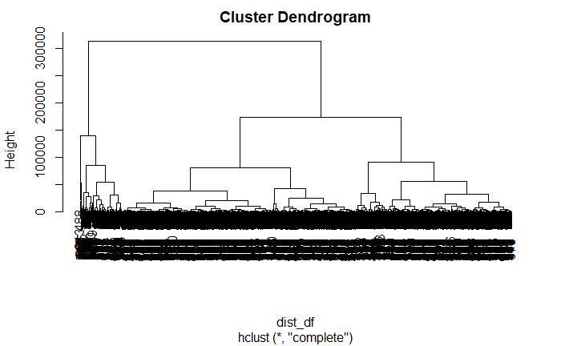

```r
dist_df <- dist(df[-8], method='euclidian')
cha <- hclust(dist_df, method='complete')
plot(cha)
```

On veut avoir 2 clusters pour bien classifier les 2 classes qu’on a

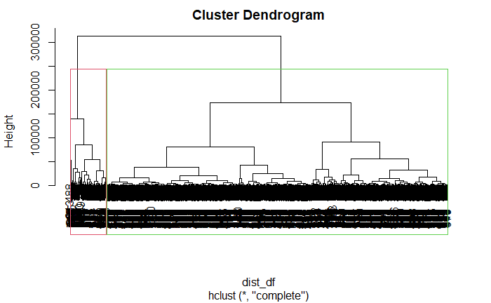

```r
cut_cha <- cutree(cha, k=2)
plot(cha)
rect.hclust(cha , k = 2, border = 2:4)
```

Par ce méthode on a une déséquilibre entre les clusters

```r
print(paste("Cluster 1: ", sum(cut_cha == 1)))
```

```
[1] "Cluster 1:  813"
```

```r
print(paste("Cluster 1: ", sum(cut_cha == 2)))
```

```
[1] "Cluster 1:  87"
```

L’erreur de classification est donc

```r
1 - mean((cut_cha == 1 & df$Class == "Kecimen") | (cut_cha == 2 & df$Class == "Besni"))
```

```
[1] 0.4077778
```

Ce erreur est plus elévé que pour l’algorithme de k-means. On veut voir maintenant si la normalisation des variables jeu un rõle dans ce résultat pour cet algorithme

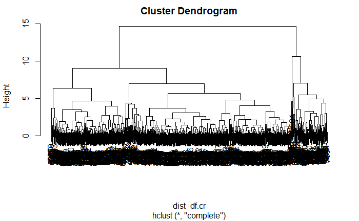

```r
dist_df.cr <- dist(df.cr[-8], method='euclidian')
cha.cr <- hclust(dist_df.cr, method='complete')
plot(cha.cr)
```

L’erreur de classification est donc

```r
cut_cha.cr <- cutree(cha.cr, k=2)
1 - mean((cut_cha.cr == 1 & df$Class == "Kecimen") | (cut_cha.cr == 2 & df$Class == "Besni"))
```

```
[1] 0.3733333
```

L’erreur de classification est plus faible pour les variables normalisées ($37.3%$).

On veut maintenant faire un clustering sur les composantes principales de l’ACP fait antérieurement.

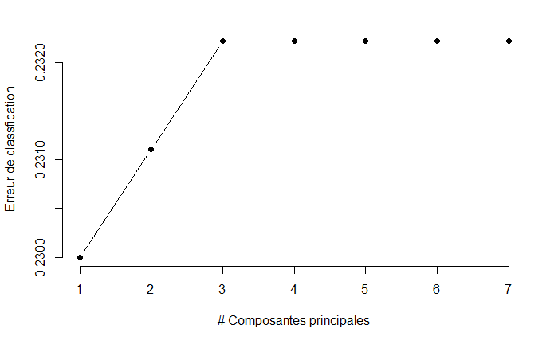

```r
k.values = 1:7
clust.errors <- function(k) {
  km <- kmeans(pca_df$ind$coord[,1:k], centers=2, nstart=10)
  min(1 - mean((km$cluster == 1 & df$Class == "Kecimen") | (km$cluster == 2 & df$Class == "Besni")),
      1 - mean((km$cluster == 2 & df$Class == "Kecimen") | (km$cluster == 1 & df$Class == "Besni")))
}
errors_values = lapply(k.values, clust.errors)
plot(k.values, errors_values,
     type="b", pch = 19, frame = FALSE,
       xlab="# Composantes principales",
       ylab="Erreur de classfication")
```

L’erreur de classification est plus faible si on prendre en compte juste la première composante principale.

# Partie II: Analyse supervisée

Pour l’analyse supervisée, on utilisera un modèle logistique, on doit attribuer un valeur 0 ou 1 a des espèces du jeu de données, la espèce Besni sera de valeur 0 et Kecimen de valeur 1. On utilisera le jeu de donnés obtenu par l’ACP

```r
df_log <- data.frame(pca_df$ind$coord)
df_log$Class = df$Class == "Kecimen"
head(df_log)
```

|  | Dim.1 | Dim.2 | Dim.3 | Dim.4 | Dim.5 | Dim.6 | Dim.7 | Class |
| --- | --- | --- | --- | --- | --- | --- | --- | --- |
| 1 | 0.07699386 | 0.4533281 | 1.0892142 | -0.02678873 | 0.1413865 | 0.01305772 | -0.003707640 | TRUE |
| 2 | -0.47537590 | -0.4453684 | -0.0163725 | 0.11594460 | 0.1219955 | 0.01380902 | -0.005672104 | TRUE |
| 3 | 0.37210892 | -0.8020081 | -0.7864871 | 0.26496260 | 0.0621901 | -0.04341853 | -0.007208510 | TRUE |
| 4 | -2.62244499 | 0.3025636 | -0.4827210 | -0.09959682 | -0.1153308 | 0.04228420 | -0.013386525 | TRUE |
| 5 | -0.96205385 | 2.9677630 | -0.4521543 | -0.29988296 | 0.1757713 | -0.05246846 | -0.006949173 | TRUE |
| 6 | -2.17316315 | -0.9244119 | -0.3451824 | 0.12941432 | -0.1392421 | 0.03887126 | 0.008374202 | TRUE |

On est dans un cas de données individuelles.

La centrage et réduction des variables explicatives ne sont pas obligatoires d’un point de vue théorique pour la régression logistique, cependant, pour la régression lasso il est nécessaire vu que la solution n’est pas la même. D’un point de vue pratique, la normalisation des variables aide l’interpretabilité du modèle lorsque les variables auront moyenne 0.

On separe le jeu de données en un ensemble *train* et un ensemble *test*

```r
set.seed(1)
train = sample(c(TRUE, FALSE), nrow(df_log), rep=TRUE, prob=c(2/3,1/3))
df_train = df_log[train,]
df_test = df_log[!train,]
```

On test différents modèles de régression logistique a) Modèle complet

```r
res.glm_complet <- glm(Class~., family="binomial", data=df_train)
summary(res.glm_complet)
```

```
Call:
glm(formula = Class ~ ., family = "binomial", data = df_train)

Deviance Residuals:
    Min       1Q   Median       3Q      Max
-2.8944  -0.4287   0.1426   0.5332   3.3731

Coefficients:
            Estimate Std. Error z value Pr(>|z|)
(Intercept)  -0.5113     0.2538  -2.014 0.043983 *
Dim.1        -1.4741     0.1731  -8.517  < 2e-16 ***
Dim.2         0.2983     0.1366   2.185 0.028911 *
Dim.3        -0.6315     0.1878  -3.363 0.000771 ***
Dim.4         0.1081     0.9509   0.114 0.909504
Dim.5         1.4508     2.1102   0.688 0.491757
Dim.6        -0.1143     2.1815  -0.052 0.958216
Dim.7        32.9632     5.7155   5.767 8.05e-09 ***
---
Signif. codes:  0 ‘***’ 0.001 ‘**’ 0.01 ‘*’ 0.05 ‘.’ 0.1 ‘ ’ 1

(Dispersion parameter for binomial family taken to be 1)

    Null deviance: 831.45  on 599  degrees of freedom
Residual deviance: 409.85  on 592  degrees of freedom
AIC: 425.85

Number of Fisher Scoring iterations: 7
```

2. Modèle avec les deux premières composantes principales

```r
res.glm_2pca <- glm(Class~Dim.1 + Dim.2, family="binomial", data=df_train)
summary(res.glm_2pca)
```

```
Call:
glm(formula = Class ~ Dim.1 + Dim.2, family = "binomial", data = df_train)

Deviance Residuals:
    Min       1Q   Median       3Q      Max
-2.7865  -0.5389   0.1375   0.5560   4.7980

Coefficients:
            Estimate Std. Error z value Pr(>|z|)
(Intercept)  -0.3150     0.1285  -2.451   0.0142 *
Dim.1        -1.3560     0.1128 -12.026  < 2e-16 ***
Dim.2         0.4778     0.1157   4.129 3.65e-05 ***
---
Signif. codes:  0 ‘***’ 0.001 ‘**’ 0.01 ‘*’ 0.05 ‘.’ 0.1 ‘ ’ 1

(Dispersion parameter for binomial family taken to be 1)

    Null deviance: 831.45  on 599  degrees of freedom
Residual deviance: 447.49  on 597  degrees of freedom
AIC: 453.49

Number of Fisher Scoring iterations: 6
```

3. En utilisant le critère d’AIC Piur cela on utilisera un méthode de *Grid Search* Pour trouver des bons valeurs pour les hyperparametres *direction* et *k*.

```r
compute_accuracy_aic <- function(x) {
  model <- stepAIC(res.glm_complet, direction=x[1], k=as.numeric(x[2]), trace=FALSE)
  predicted <- predict(model, df_test[-8]) > 0.5
  mean(predicted == df_test[8])
}


gs <- list(direction=c("both", "backward", "forward"),
           k = c(2, log(nrow(df_log))))

res_gs <- gridSearch(compute_accuracy_aic, levels=gs)
```

```
2 variables with 3, 2 levels: 6 function evaluations required.
```

```r
res_gs
```

```
$minfun
[1] 0.8333333

$minlevels
[1] "both" "2"

$values
[1] 0.8333333 0.8333333 0.8366667 0.8333333 0.8333333 0.8366667

$levels
$levels[[1]]
[1] "both" "2"

$levels[[2]]
[1] "backward" "2"

$levels[[3]]
[1] "forward" "2"

$levels[[4]]
[1] "both"             "6.80239476332431"

$levels[[5]]
[1] "backward"         "6.80239476332431"

$levels[[6]]
[1] "forward"          "6.80239476332431"
```

On voit que l’evaluation d’hyperparametres ne change pas beaucoup la metrique utilisé, on rest donc avec les parametres originaux.

```r
res.glm_aic <- stepAIC(res.glm_complet)
```

```
Start:  AIC=425.85
Class ~ Dim.1 + Dim.2 + Dim.3 + Dim.4 + Dim.5 + Dim.6 + Dim.7

        Df Deviance    AIC
- Dim.6  1   409.86 423.86
- Dim.4  1   409.87 423.87
- Dim.5  1   410.34 424.34
<none>       409.85 425.85
- Dim.2  1   414.64 428.64
- Dim.3  1   420.92 434.92
- Dim.7  1   431.67 445.67
- Dim.1  1   781.90 795.90

Step:  AIC=423.86
Class ~ Dim.1 + Dim.2 + Dim.3 + Dim.4 + Dim.5 + Dim.7

        Df Deviance    AIC
- Dim.4  1   409.87 421.87
- Dim.5  1   410.37 422.37
<none>       409.86 423.86
- Dim.2  1   415.51 427.51
- Dim.3  1   420.99 432.99
- Dim.7  1   436.85 448.85
- Dim.1  1   782.60 794.60

Step:  AIC=421.87
Class ~ Dim.1 + Dim.2 + Dim.3 + Dim.5 + Dim.7

        Df Deviance    AIC
- Dim.5  1   410.38 420.38
<none>       409.87 421.87
- Dim.2  1   415.64 425.64
- Dim.3  1   422.25 432.25
- Dim.7  1   438.32 448.32
- Dim.1  1   782.62 792.62

Step:  AIC=420.38
Class ~ Dim.1 + Dim.2 + Dim.3 + Dim.7

        Df Deviance    AIC
<none>       410.38 420.38
- Dim.2  1   419.21 427.21
- Dim.3  1   422.25 430.25
- Dim.7  1   440.87 448.87
- Dim.1  1   797.69 805.69
```

Le modèle obtenu tulise les 3 premières et la septième composantes principales.

4. Régression pénalisée lasso. Pour cela on utilise une validation croisée pour trouver un valeur de lambda optimal

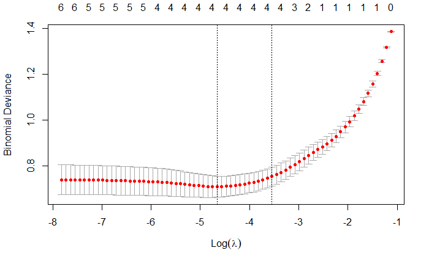

```r
cv.lasso <- cv.glmnet(as.matrix(df_train[,-8]), df_train[,8], alpha=1, family='binomial')
plot(cv.lasso)
```

On a le valeur optimal de lambda et les paramètres du modèle trouvé

```r
cv.lasso$lambda.min
```

```
[1] 0.00946155
```

```r
coef(cv.lasso)
```

```
8 x 1 sparse Matrix of class "dgCMatrix"
                    s1
(Intercept) -0.1900628
Dim.1       -0.9540874
Dim.2        0.1316033
Dim.3       -0.1599468
Dim.4        .
Dim.5        .
Dim.6        .
Dim.7       12.7256696
```

On peut donc générer un modèle

```r
res.glm_lasso <- glmnet(df_train[,-8], df_train[,8], family="binomial", lambda=cv.lasso$lambda.min)
```

5. Modèle SVM linéaire On utilisera du méthode de *grid search* pour trouver les meilleur valeur de coût pour le SVM linéaire

```r
svm_lin <- best.svm(df_train[,-8], y=as.numeric(df_train[,8]), kernel="linear",
         cost=c(10, 1, 0.1, 0.01, 0.001, 0.0001))

svm_lin$cost
```

```
[1] 0.01
```

On a $C = 0.01$ idéalement pour ce jeu de données

6. Modèle SVM polynomial

```r
svm_poly <- best.svm(df_train[,-8], y=as.numeric(df_train[,8]), kernel='polynomial',
                     cost=c(1, 0.1, 0.01),
                     gamma=c(0.1, 0.01),
                     degree=c(2, 4, 6),
                     coef0=c(0, 1))
svm_poly
```

```
Call:
best.svm(x = df_train[, -8], y = as.numeric(df_train[, 8]), kernel = "polynomial", cost = c(1,
    0.1, 0.01), gamma = c(0.1, 0.01), degree = c(2, 4, 6), coef0 = c(0, 1))


Parameters:
   SVM-Type:  eps-regression
 SVM-Kernel:  polynomial
       cost:  0.1
     degree:  4
      gamma:  0.1
     coef.0:  1
    epsilon:  0.1


Number of Support Vectors:  415
```

On a maintenant les 6 modèles, on les compare.

On trace la courbe ROC pour le modèle complet sur les échantillon d’apprentissage et de test

```r
roc_complet_train <- roc(df_train[,8], predict(res.glm_complet, newdata=df_train[,-8]))
roc_complet_test <- roc(df_test[,8], predict(res.glm_complet, newdata=df_test[,-8]))
auc_complet_train <- auc(roc_complet_train)
```

```r
model_list = list()
labels = c("2 CP", "AIC", "Lasso", "SVM Lin", "SVM Poly")
i <- 0
for (model in list(res.glm_2pca, res.glm_aic, res.glm_lasso, svm_lin, svm_poly)) {
  if ("glmnet" %in% class(model)) {
    roc <- roc(df_test[,8], predict(model, as.matrix(df_test[,-8])))
  }
  else {
    roc <- roc(df_test[,8], predict(model, df_test[,-8]))
  }
  auc <- auc(roc)

  model_list <- append(model_list, list(roc))
  i <- i+1
  labels[i] <- paste(labels[i], " AUC = ", round(auc,3))
}
```

```
Warning in roc.default(df_test[, 8], predict(model, as.matrix(df_test[,  :
  Deprecated use a matrix as predictor. Unexpected results may be produced, please pass a numeric vector.
```

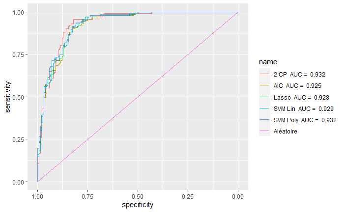

```r
ggroc(model_list)+
  scale_color_discrete(labels=append(labels, "Aléatoire")) +
  geom_segment(aes(x=1, y=0, xend=0, yend=1, color='Aléatoire'))
```

Pour les modèles essayés, on a l’AUC plus grande pour le SVM Polynomial et la régression logistique sur les 2 premières composantes principales.

On calcule l’erreur de classification pour les modéles sur les échantillons d’apprentissage et de test

```r
model_list =list(res.glm_complet, res.glm_2pca, res.glm_aic, res.glm_lasso, svm_lin, svm_poly)
labels = c("Complet", "2.CP", "AIC", "Lasso", "SVM.Lin", "SVM.Poly")
erreurs_df <- data.frame(matrix(ncol=3, nrow=0))
colnames(erreurs_df) <- c("model", "train", "test")
i <- 0
for (model in model_list) {
  i <- i+1
  if ("glmnet" %in% class(model)) {
    row <- list(model = labels[i],
                   train=1-mean(df_train[,8] == (predict(model, as.matrix(df_train[,-8])) > 0.5)),
                   test=1-mean(df_test[,8] == (predict(model, as.matrix(df_test[,-8])) > 0.5)))
  }
  else {
    row <- list(model=labels[i],
                   train=1-mean(df_train[,8] == (predict(model, df_train[,-8]) > 0.5)),
                   test=1-mean(df_test[,8] == (predict(model, df_test[,-8]) > 0.5)))
  }

  erreurs_df[i,] <- row
}

erreurs_df
```

|  | model | train | test |
| --- | --- | --- | --- |
| 1 | Complet | 0.1633333 | 0.1633333 |
| 2 | 2.CP | 0.1516667 | 0.1433333 |
| 3 | AIC | 0.1666667 | 0.1666667 |
| 4 | Lasso | 0.1633333 | 0.1633333 |
| 5 | SVM.Lin | 0.1400000 | 0.1333333 |
| 6 | SVM.Poly | 0.1283333 | 0.1400000 |

On voit que l’erreur de test du SVM linéaire est plus faible que les autres modèles. Le SVM polynomial a un erreur de apprentissage plus faible, cela peut indiquer une sur apprentissage et une variance plus grande pour ce modèle. On retient le modéle SVM linéaire lorsque il s’adapte mieux aux donnés pas encore vues.

# Partie III: Analyse discriminante

On commence par calculer la projection des données de test sur le plan principal associée au jeu d’apprentissage

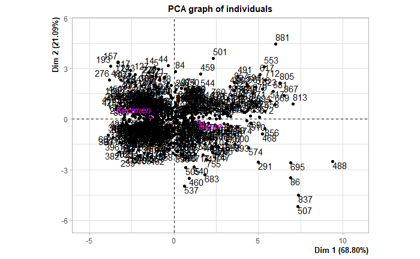

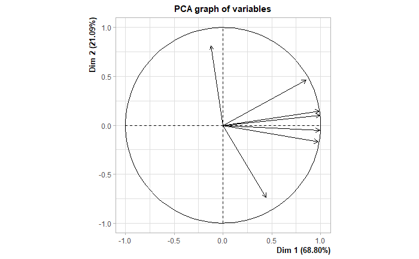

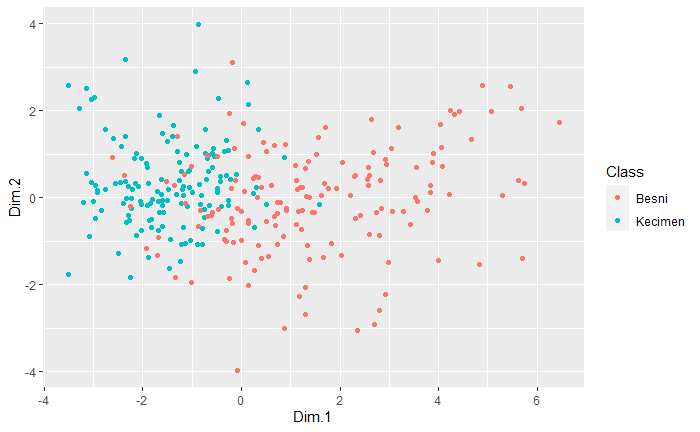

## Analyse Discriminante Linéaire (LDA)

L’analyse discriminante fait la supposition que les variables ont des distributions gaussiennes, de même variance entre les classes, on a la probabilité a posteriori.

$\pi_c(x) = \mathbb{P}(Y_c = 1|X = x) = \frac{\mathbb{P}(Y=c)exp-\frac{1}{2}[(x-\mu_c)'\Sigma^{-1}(x-\mu_c)]}{ \sum _l\mathbb{P}(Y=l)exp-\frac{1}{2}[(x-\mu_l)'\Sigma^{-1}(x-\mu_l)]}$

On cherche c qui maximise $\pi_c(x)$.

Le classifieur associée s’est écrit comme $\delta_c(x) = x'\Sigma^{-1}\mu_c-\frac{1}{2}\mu_c'\Sigma^{-1}\mu_c + log(\pi_c)$

On définit aussi le classifieur pour deux classes comme une frontière $\overrightarrow{\omega} \cdot \overrightarrow{x} > c$

On calcule les valeurs des coefficients comme

$\overrightarrow{\omega} = \Sigma^{-1}(\overrightarrow{\mu_1} - \overrightarrow{\mu_0})$

$c = \overrightarrow{\omega} \cdot \frac{1}{2}(\overrightarrow{\mu_1} + \overrightarrow{\mu_0})$

On estime les paramètres par la méthode du maximum de vraisemblance

```r
print(list(omega=omega, c=c))
```

```
$omega
            [,1]
Dim.1 -2.8499278
Dim.2  0.3055202

$c
           [,1]
[1,] -0.0958467
```

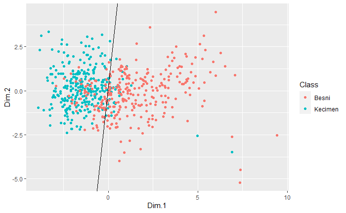

On calcule l’erreur sur le jeu de test

```r
1- mean(sapply(as.matrix(proj_test[,1:2]) %*% omega, function(x) {x > c}) == (proj_test$Class == "Kecimen"))
```

```
[1] 0.1433333
```

On a un erreur de $14.33\%$ pour le LDA, comme on a calculé à la main, on veut maintenant vérifier le valeur avec la fonction *lda* du package *MASS* et la fonction *predict*

```r
lda_pca2
```

```
Call:
lda(Class ~ Dim.1 + Dim.2, data = df_pca2)

Prior probabilities of groups:
    Besni   Kecimen
0.4883333 0.5116667

Group means:
            Dim.1      Dim.2
Besni    1.458213 -0.1563245
Kecimen -1.391715  0.1491957

Coefficients of linear discriminants:
             LD1
Dim.1 -0.5953096
Dim.2  0.2082017
```

```r
1-mean(predict(lda_pca2, newdata=proj_test[,1:2])$class == proj_test$Class)
```

```
[1] 0.1433333
```

On confirme le valeur calculé à la main obtenu antérieurement

On considère maintenant toutes les variables initiales du jeu de données

```r
lda_pca_complet <- lda(Class~., data=df_pca2)
lda_pca_complet
```

```
Call:
lda(Class ~ ., data = df_pca2)

Prior probabilities of groups:
    Besni   Kecimen
0.4883333 0.5116667

Group means:
            Dim.1      Dim.2      Dim.3       Dim.4       Dim.5        Dim.6        Dim.7
Besni    1.458213 -0.1563245  0.0927095  0.01306797  0.01723814 -0.005643134 -0.006525001
Kecimen -1.391715  0.1491957 -0.0884817 -0.01247204 -0.01645203  0.005385792  0.006227444

Coefficients of linear discriminants:
             LD1
Dim.1 -0.5906862
Dim.2  0.2065847
Dim.3 -0.2929128
Dim.4 -0.4213520
Dim.5 -1.5368785
Dim.6  1.6689836
Dim.7 11.9834554
```

```r
1-mean(predict(lda_pca_complet, newdata=proj_test[,1:7])$class == proj_test$Class)
```

```
[1] 0.1433333
```

On obtient le même erreur de $14.33\%$. Ce résultat est inférieur par $1\%$ que le meilleur résultat obtenu par le SVM linéaire $13.33\%$ sur le jeu de test.

# Conclusion

On peut conclure que pour ce jeu de données e entre les méthodes essayées, le SVM est plus performante dans la métrique de **précision** que les autres modèles. On le retient.